# STAT 302 SPR2020 Lecture 13

Sheridan Grant

May 11, 2020

## Preliminaries

Libraries:

```r
library(tidyverse)
library(caret)
```

Helper functions:

```r
# e^x/(e^x+1) for input x
expit <- function(x) exp(x)/(exp(x) + 1)

# root mean squared error for true y and prediction yhat
rmse <- function(y,yhat) sqrt(mean((y-yhat)^2))
# accuracy for predictions yhat and true binary outcome y
acc <- function(y, yhat) mean(y == yhat)
```

## Cross-Validation

Split the data frame into 4 parts. This sets up the indexing.

```r
faithfulGrid <- data.frame(waiting = seq(35,105))
n <- dim(faithful)[1]
k <- 4
randomInd <- sample(n)
splitSize <- n/k  # Only works if n/k is an integer. Use caret package!
```

Train on 3/4 of data 4 times, leaving out a different 1/4 for testing each time. Here we plot the 4 estimated models. The indexing is an absolute nightmare, as you can see, and this is the special case when n/k is an integer. Indexing with a minus sign first *removes* indices.

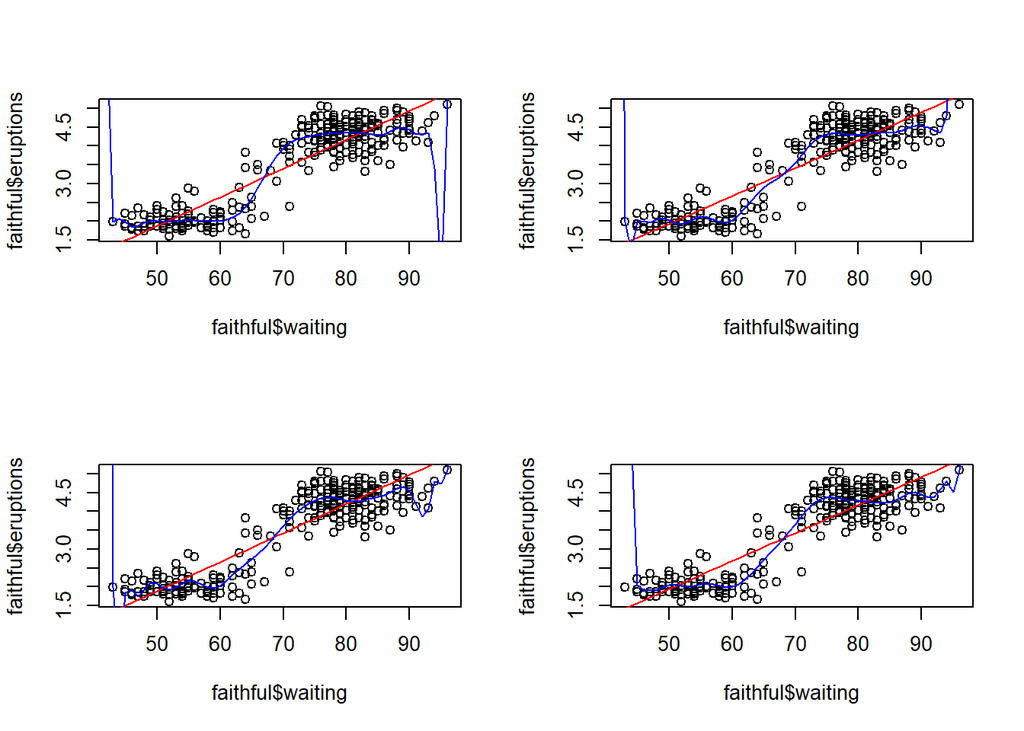

```r
linMods <- lapply(1:k, function(i) lm(eruptions ~ waiting,
data = faithful[randomInd[-((splitSize*(i-1)+1):(splitSize*i))],]))

deg <- 20
polMods <- lapply(1:k, function(i) lm(eruptions ~ poly(waiting,deg),
data = faithful[randomInd[-((splitSize*(i-1)+1):(splitSize*i))],]))

par(mfrow=c(2,2))
for (i in 1:k) {
  plot(faithful$waiting, faithful$eruptions)
  lines(faithfulGrid$waiting, predict(linMods[[i]], faithfulGrid), col = 'red')
  lines(faithfulGrid$waiting, predict(polMods[[i]], faithfulGrid), col = 'blue')
}
```

RMSEs from CV: test on the left-out 1/4 of the data. You will not have to do this indexing yourself.

```r
linRMSEs <- sapply(1:k,
                   function(i) rmse(faithful$eruptions[randomInd[(splitSize*(i-1)+1):(splitSize*i)]],
                                    predict(linMods[[i]],
                                            faithful[randomInd[(splitSize*(i-1)+1):(splitSize*i)],])))

polRMSEs <- sapply(1:k,
                   function(i) rmse(faithful$eruptions[randomInd[(splitSize*(i-1)+1):(splitSize*i)]],
                                    predict(polMods[[i]],
                                            faithful[randomInd[(splitSize*(i-1)+1):(splitSize*i)],])))
mean(linRMSEs)
```

```
## [1] 0.4974443
```

```r
mean(polRMSEs)
```

```
## [1] 2.267071
```

Caret package makes CV (cross-validation easier).

```r
folds4 <- createFolds(sample(n), k)
linModsCaret <- lapply(folds4, function(fold) lm(eruptions ~ waiting,
                                                 data = faithful[-fold,]))
linRMSEsCaret <- sapply(1:k, function(i) rmse(faithful$eruptions[folds4[[i]]],
                                              predict(linModsCaret[[i]],
                                                      faithful[folds4[[i]],])))

mean(linRMSEsCaret)
```

```
## [1] 0.4989214
```

Still isn’t pretty, though.

## Binary Outcomes

We know how to handle binary and categorical predictor variables. How about outcomes?

```r
votes115 <- read_csv('../data/S115_votes.csv')
members115 <- read_csv('../data/S115_members.csv')
joint115 <- inner_join(votes115, members115, by = 'icpsr')  # link records on senator ID
dim(joint115)
```

```
## [1] 60008    27
```

```r
unique(joint115$cast_code)
```

```
## [1] 1 6 9 7
```

```r
joint115 <- joint115 %>% filter(cast_code %in% c(1,6),
                                party_code %in% c(100,200))
joint115$party <- ifelse(joint115$party_code == 100, 'D', 'R')
joint115$yay <- (joint115$cast_code == 1)
```

How likely are senators from each party to vote to pass bills? 115th congress (2017-2019).

```r
# Logistic regression
partyMod <- glm(yay ~ party, data = joint115, family = 'binomial')
summary(partyMod)
```

```
##
## Call:
## glm(formula = yay ~ party, family = "binomial", data = joint115)
##
## Deviance Residuals:
##     Min       1Q   Median       3Q      Max
## -1.9119  -1.1718   0.5921   0.5921   1.1830
##
## Coefficients:
##             Estimate Std. Error z value Pr(>|z|)
## (Intercept) -0.01316    0.01213  -1.085    0.278
## partyR       1.66548    0.01984  83.930   <2e-16 ***
## ---
## Signif. codes:  0 '***' 0.001 '**' 0.01 '*' 0.05 '.' 0.1 ' ' 1
##
## (Dispersion parameter for binomial family taken to be 1)
##
##     Null deviance: 72072  on 57240  degrees of freedom
## Residual deviance: 64206  on 57239  degrees of freedom
## AIC: 64210
##
## Number of Fisher Scoring iterations: 3
```

Which party controlled the Senate 2017-2019?

What do the coefficient estimates mean?

```r
cat('Prob D votes yay:', expit(coef(partyMod)[1]),
    '\nProb R votes yay:', expit(sum(coef(partyMod))), '\n\n')
```

```
## Prob D votes yay: 0.4967106
## Prob R votes yay: 0.8392048
```

We didn’t need a fancy model for this, actually:

```r
joint115 %>% group_by(party) %>% summarize(yayProb = mean(yay))
```

```
## # A tibble: 2 x 2
##   party yayProb
##   <chr>   <dbl>
## 1 D       0.497
## 2 R       0.839
```

It gets interesting when continuous covariates are included:

```r
nomMod <- glm(yay ~ nominate_dim1*nominate_dim2,
              data = joint115, family = 'binomial')
summary(nomMod)
```

```
##
## Call:
## glm(formula = yay ~ nominate_dim1 * nominate_dim2, family = "binomial",
##     data = joint115)
##
## Deviance Residuals:
##    Min      1Q  Median      3Q     Max
## -2.211  -1.122   0.586   0.821   1.536
##
## Coefficients:
##                             Estimate Std. Error z value Pr(>|z|)
## (Intercept)                  0.70765    0.01041   67.96  < 2e-16 ***
## nominate_dim1                1.88239    0.02644   71.19  < 2e-16 ***
## nominate_dim2                0.57395    0.03928   14.61  < 2e-16 ***
## nominate_dim1:nominate_dim2  0.37326    0.09547    3.91 9.23e-05 ***
## ---
## Signif. codes:  0 '***' 0.001 '**' 0.01 '*' 0.05 '.' 0.1 ' ' 1
##
## (Dispersion parameter for binomial family taken to be 1)
##
##     Null deviance: 71981  on 57123  degrees of freedom
## Residual deviance: 63878  on 57120  degrees of freedom
##   (117 observations deleted due to missingness)
## AIC: 63886
##
## Number of Fisher Scoring iterations: 4
```

Predict for a different congress (103rd, 1993-1995). Extrapolation or no?

```r
votes103 <- read_csv('../data/S103_votes.csv')
members103 <- read_csv('../data/S103_members.csv')
joint103 <- inner_join(votes103, members103, by = 'icpsr')
dim(joint103)
```

```
## [1] 73124    27
```

```r
unique(joint103$cast_code)
```

```
## [1] 1 6 9 7
```

```r
joint103 <- joint103 %>% filter(cast_code %in% c(1,6),
                                party_code %in% c(100,200))
joint103$party <- ifelse(joint103$party_code == 100, 'D', 'R')
joint103$yay <- (joint103$cast_code == 1)
```

```r
predProbsParty <- expit(predict(partyMod, joint103))
acc(joint103$yay, predProbsParty > 0.5)
```

```
## [1] 0.3865581
```

```r
predProbsNom <- expit(predict(nomMod, joint103))
acc(joint103$yay, predProbsNom > 0.5)
```

```
## [1] 0.5536544
```

```r
mean(joint115$yay)
```

```
## [1] 0.6764033
```

```r
acc(joint103$yay, 1)
```

```
## [1] 0.643796
```

## Plot Generating for Slides

In case you’re curious how I make slides.

Linear regression:

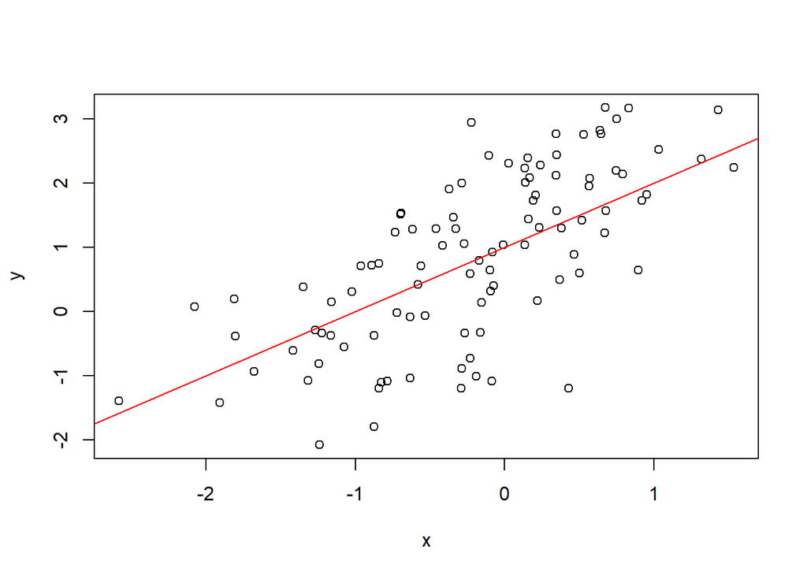

```r
x <- rnorm(100)
y <- 1 + x + rnorm(100)
plot(x, y, main = '')
abline(1, 1, col = 'red')
```

Logistic regression:

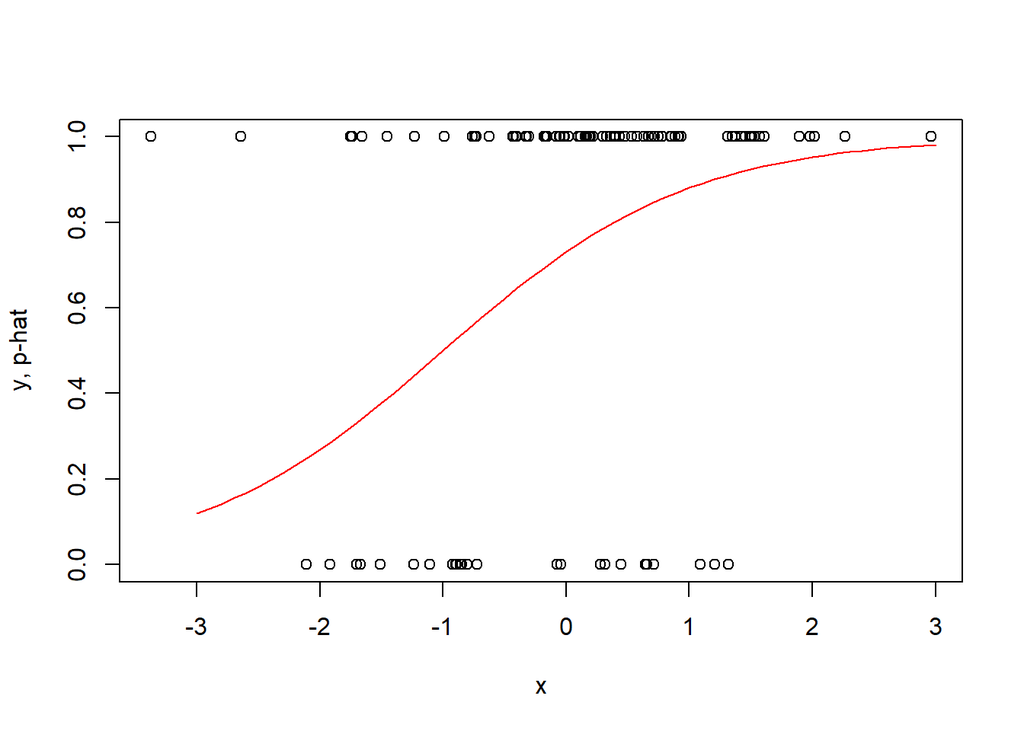

```r
x <- rnorm(100)
probs <- expit(1 + x + rnorm(100))
y <- rbinom(100, 1, probs)
plot(x, y, main = '', ylab = 'y, p-hat')
lines(seq(-3,3,.1), expit(1 + seq(-3,3,.1)), col = 'red')
```